# Part 1

Karol Szwed

2024-06-02

# 1. Eksploracja danych

```r
X_test <- read.csv("X_test.csv")
X_train <- read.csv("X_train.csv")
Y_train <- read.csv("y_train.csv")
```

## $a)$ Rozmiar danych i typ zmiennych

Widzimy, że dane treningowe składają się z $6800$ obserwacji i $9000$ zmiennych objaśniających. Dane testowe składają się z $1200$ obserwacji i $9000$ zmiennych objaśniających. Zmienna objaśniana (białko $CD36$) jest jednowymiarowa. Wszystkie zmienne są typu ‘double’, co jest zgodne z oczekiwaniami. Tym samym nie dokonujemy konwersji typów zmiennych. Nie ma braków danych.

```r
print("Dane treningowe - RNA")
```

```
## [1] "Dane treningowe - RNA"
```

```r
print(dim(X_train))
```

```
## [1] 6800 9000
```

```r
print("Dane treningowe - białko powierzchniowe")
```

```
## [1] "Dane treningowe - białko powierzchniowe"
```

```r
print(dim(Y_train))
```

```
## [1] 6800    1
```

```r
print("Dane testowe - RNA")
```

```
## [1] "Dane testowe - RNA"
```

```r
print(dim(X_test))
```

```
## [1] 1200 9000
```

```r
# Typ zmiennych - wszystkie powinny być typu 'double'
print("Czy wszystkie zmienne są typu double:")
```

```
## [1] "Czy wszystkie zmienne są typu double:"
```

```r
print(all(sapply(X_test, is.double)))
```

```
## [1] TRUE
```

```r
print(all(sapply(X_train, is.double)))
```

```
## [1] TRUE
```

```r
print(all(sapply(Y_train, is.double)))
```

```
## [1] TRUE
```

```r
print("Czy są braki danych:")
```

```
## [1] "Czy są braki danych:"
```

```r
# Sprawdzenie czy są braki danych
print(any(sapply(X_test, is.na)))
```

```
## [1] FALSE
```

```r
print(any(sapply(X_train, is.na)))
```

```
## [1] FALSE
```

```r
print(any(sapply(Y_train, is.na)))
```

```
## [1] FALSE
```

## $b)$ Rozkład zmiennej objaśnianej

```r
# Badamy rozkład zmiennej objaśnianej (dane 'Y_train')
summary(Y_train)
```

```
##       CD36
##  Min.   :0.0000
##  1st Qu.:0.0000
##  Median :0.5437
##  Mean   :1.0862
##  3rd Qu.:1.9612
##  Max.   :5.1264
```

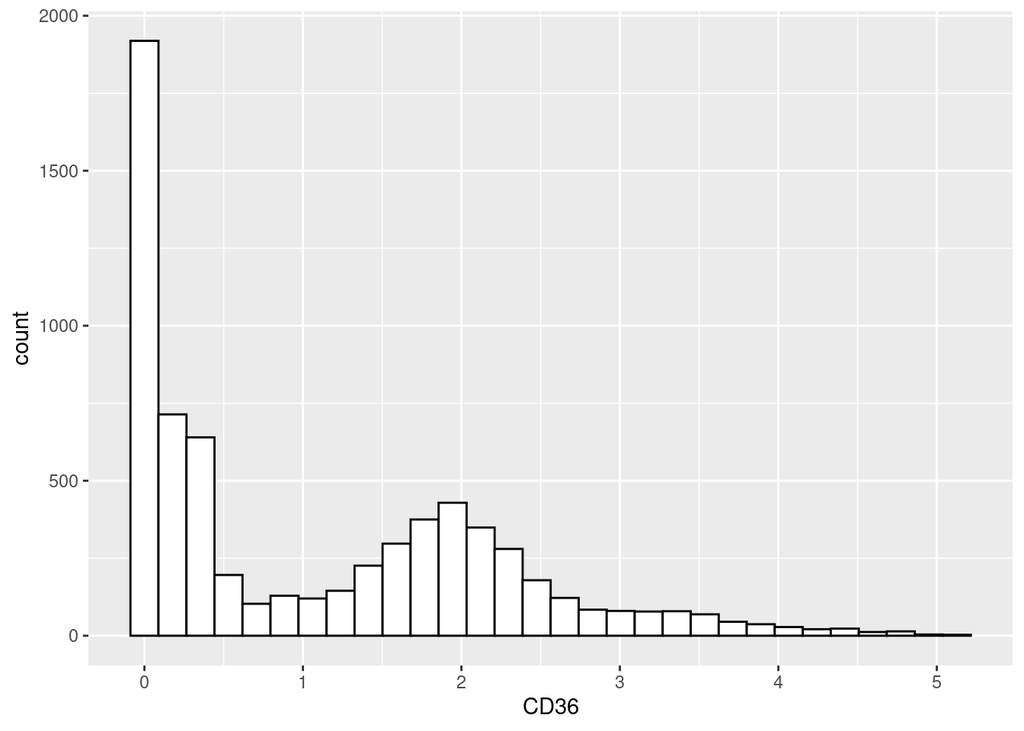

```r
# Histogram
ggplot(data = Y_train, aes(x = CD36)) + geom_histogram(color="black", fill="white")
```

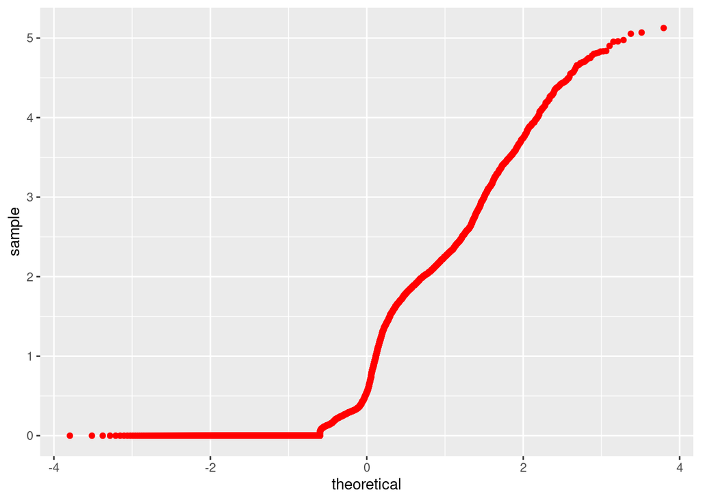

```r
# Wykres kwantylowy
ggplot(data = Y_train) + geom_qq(aes(sample = CD36), size=1.5, color="red")
```

## $c)$ Korelacja zmiennych

Obrazujemy korelację zmiennych na mapie ciepła. Wybieramy $250$ zmiennych o największej korelacji z zmienną objaśnianą. Widać, że niektóre zmienne są ze sobą mocno skorelowane.

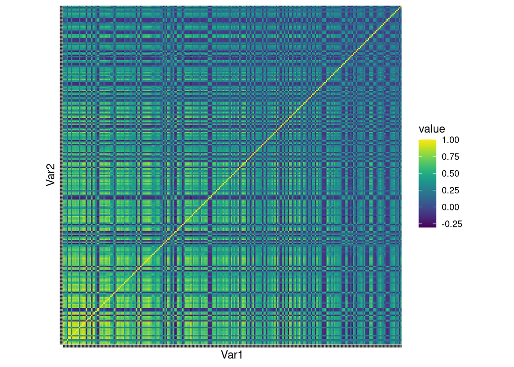

```r
# Korelacja zmiennych
# Wybieramy 250 zmiennych o największej korelacji z zmienną objaśnianą
correlated <- apply(X_train, 2, function (x) cor(x, Y_train))
X_high_cor <- X_train[, order(correlated, decreasing = T)[1:250]]

# Macierz korelacji
cor_matrix <- cor(X_high_cor)
cor_relations <- melt(cor_matrix)

# Ilustrujemy wynik za pomocą mapy ciepła
library(viridis)
Var.heatmap <- ggplot(data = cor_relations, mapping = aes(x = Var1,
                                                          y = Var2,
                                                          fill = value)) +
  geom_tile() + scale_fill_viridis(discrete=FALSE) +
  theme(axis.text.x = element_blank(), axis.text.y = element_blank()) +
  coord_fixed()

print(Var.heatmap)
```

# 2. Testy statystyczne

## $a)$ Wykres kwantylowy

Najpierw rysujemy wykres kwantylowy porównujący zmienną objaśnianą z rozkładem normalnym.

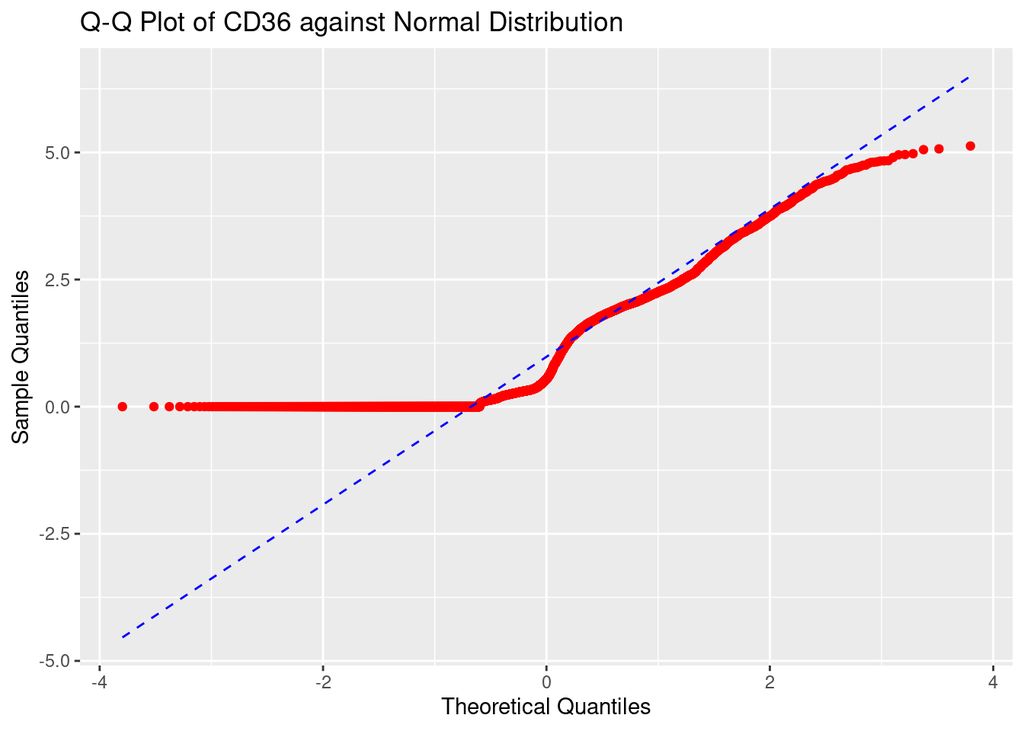

```r
qq_plot <- ggplot(data = Y_train, aes(sample = CD36)) +
  geom_qq(color = "red", size = 1.5) +
  geom_qq_line(color = "blue", linetype = "dashed") +
  labs(title = "Q-Q Plot of CD36 against Normal Distribution",
       x = "Theoretical Quantiles",
       y = "Sample Quantiles")

print(qq_plot)
```

Nie jesteśmy w stanie odczytać średniej z tego wykresu, natomiast kształt litery ‘S’ wykresu doświadczalnego (mocno spłaszczony z lewej) wskazuje na wariancję mniejszą niż rozkładu normalnego.

## $b)$ Test hipotezy zgodności z rozkładem normalnym

$H_0$ - rozkład zmiennej objaśnianej pochodzi z rozkładu normalnego $H_1$ - rozkład zmiennej nie pochodzi z rozkładu normalnego

$\alpha$ - ustalamy poziom istotności na poziomie 0.01

```r
x <- Y_train$CD36
ad_result <- ad.test(x, "pnorm", mean=mean(x), sd=sd(x), estimated=TRUE)

print(ad_result)
```

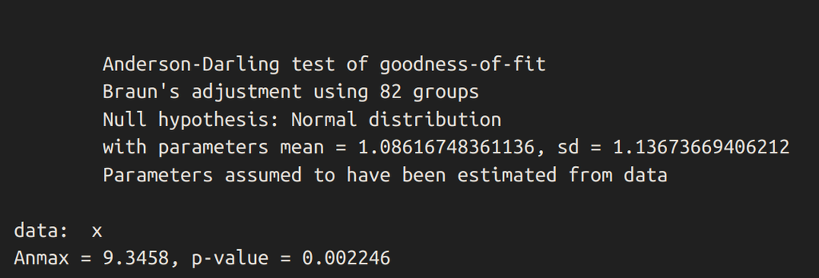

Test zgodności A-D

Z uwagi na wyniku testu (zarówno dużą wartość statystyki $A$ oraz małe $p\text{-value}$) odrzucamy hipotezę zerową. Stąd przyjmujemy, że test nie pochodzi z rozkładu normalnego.

## $c)$ Pozostałe testy statystyczne dla jednej zmiennej objaśniającej

Na początku wybierzmy jedną zmienną objaśniającą najbardziej skorelowaną ze zmienną objaśnianą.

```r
cor_vec <- cor(X_train, Y_train)
max_cor_index <- which.max(cor_vec)
most_correlated_var_name <- colnames(X_train)[max_cor_index]

cat("Najbardziej skorelowaną zmienną objaśniającą jest:", most_correlated_var_name, "z korelacją: ", cor_vec[max_cor_index], "\n")
```

```
## Najbardziej skorelowaną zmienną objaśniającą jest: BLVRB z korelacją:  0.6179235
```

### $i.$ Test zgodności z rozkładem wykładniczym o $\lambda = 8$

Na podstawie poniższego wykresu przeprowadzę test zgodności zmiennej z rozkładem wykładniczym o parametrze $\lambda = 8$.

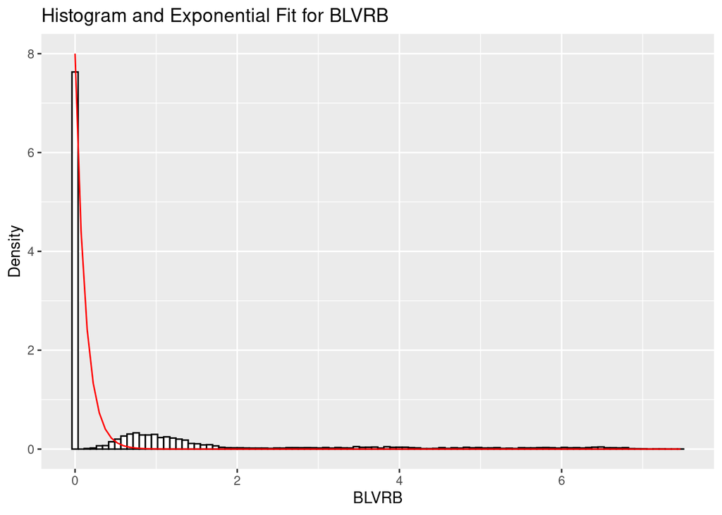

```r
lambda <- 8

p <- ggplot(data = X_train, aes_string(x = most_correlated_var_name)) +
  geom_histogram(aes(y = ..density..), color = "black", fill = "white", bins = 100) +
  stat_function(fun = function(x) dexp(x, rate = lambda), color = "red") +
  labs(title = paste("Histogram and Exponential Fit for", most_correlated_var_name),
       x = most_correlated_var_name,
       y = "Density")
print(p)
```

Ponownie wykorzystam do tego test Andersona-Darlinga. Możemy z niego skorzystać, gdyż nie ma potrzeby estymacji parametrów testowanej dystrybucji.

$H_0$ - rozkład zmiennej objaśnianej pochodzi z rozkładu wykładniczego, $\lambda = 8$ $H_1$ - rozkład zmiennej nie pochodzi z tego rozkładu

$\alpha$ - ustalamy poziom istotności na poziomie 0.01

```r
test_data <- X_train[[most_correlated_var_name]]
exp_cdf <- function(x) 1 - exp(-8 * x)
ad_result <- ad.test(test_data, exp_cdf)

print(ad_result)
```

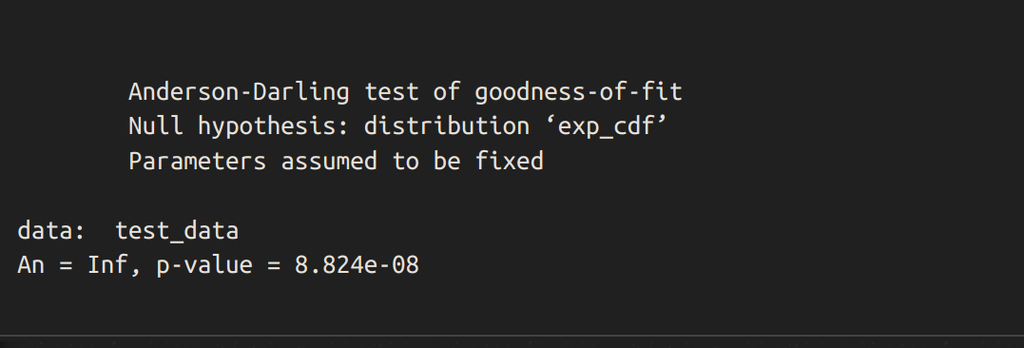

Test zgodności A-D z rozkładem wykładnicznym

Tym samym odrzucamy hipotezę zerową ($\alpha < 0$), iż rozkład zmiennej objaśniającej najbardziej skorelowanej ze zmienną objaśnianą pochodzi z rozkładu wykładniczego o paramatrze $\lambda = 8$.

### $ii.$ Test lokalizacji rozkładu w zbiorze testowym i treningowym

Sprawdzimy za pomocą testu Manna-Whitney’a, czy wybrana przez nas zmienna objaśniająca ma taką samą medianę w zbiorze testowym i treningowym.

$H_0$ - rozkłady zmiennej w obu zbiorach są tak samo zlokalizowane vs. $H_1$ - rozkłady zmiennej w obu zbiorach nie są tak samo zlokalizowane

$\alpha$ - ustalamy poziom istotności na poziomie 0.05

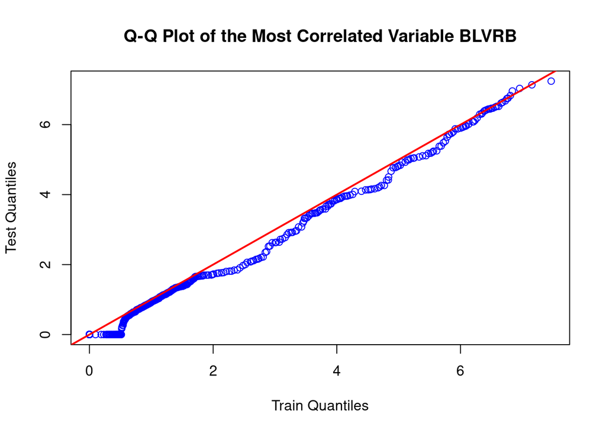

```r
# Wybieramy podzbioór danych zawierający naszą najbardziej skorelowaną zmienną
train_data <- X_train[, most_correlated_var_name]
test_data <- X_test[, most_correlated_var_name]

# Rysujemy wykres kwantylowy
qqplot(train_data, test_data, main = paste("Q-Q Plot of the Most Correlated Variable", most_correlated_var_name),
       xlab = "Train Quantiles", ylab = "Test Quantiles", col = "blue", pch = 1)

# Dodajemy prostą nachyloną pod kątem 45 st.
abline(0, 1, col = "red", lwd = 2)
```

Tym samym widzimy, że wybrana zmienna objaśniająca ma podobny rozkład w zbiorze testowym oraz treningowym, tym samym test Manna-Whitney’a jest poprawny.

```r
test_result <- wilcox.test(train_data, test_data, alternative = "two.sided")

print(test_result)
```

```
##
##  Wilcoxon rank sum test with continuity correction
##
## data:  train_data and test_data
## W = 4200048, p-value = 0.06969
## alternative hypothesis: true location shift is not equal to 0
```

Otrzymaliśmy $p\text{-value} > \alpha$, więc nie ma podstaw do odrzucenia hipotezy zerowej, więc rozkład wybranej zmiennej jest zlokalizowany tak samo w zbiorze testowym oraz treningowym.

# 3. ElasticNet

## $a)$ Opis modelu ElasticNet

*ElasticNet* jest metodą regularyzowanej regresji, która liniowo łączy w sobie dwa rodzaje regularyzacji: $\ell_1$ (*LASSO*) i $\ell_2$ (*Ridge*). Regularyzacja $\ell_1$ redukuje współczynniki modelu do zera, co pozwala na selekcję zmiennych. Regularyzacja $\ell_2$ z kolei zmniejsza wartości współczynników, ale nie redukuje ich do zera. Dzięki temu model *ElasticNet* łączy w sobie zalety obu metod, co pozwala na selekcję zmiennych oraz zmniejszenie wariancji modelu.

Model ten jest szczególnie przydatny przy dużych zbiorach danych, które zawierają wiele zmiennych współliniowych lub kiedy liczba zmiennych jest większa od liczby obserwacji. W naszym przypadku, gdzie mamy do czynienia z $9000$ zmiennymi i $6800$ obserwacjami, model *ElasticNet* może okazać się bardzo przydatny.

Model *ElasticNet* optymalizuje parametry regresji $\beta$. Te współczynniki obrazują zależność między zmiennymi objaśniającymi a zmienną objaśnianą. Model ten minimalizuje następującą funkcję straty:

$$\underset{\beta}{\min} \left\{
\frac{1}{2n} \sum_{i=1}^n (y_i - X_i \beta)^2 + \lambda \left( \alpha
\sum_{j=1}^p |\beta_j| + \frac{1}{2} (1 - \alpha) \sum_{j=1}^p \beta_j^2
\right) \right\}$$

gdzie:

- $n$ - liczba obserwacji.
- $y_i$ - zmienna objaśniana.
- $X_i$ - wektor zmiennych objaśniających.
- $\beta$ - wektor współczynników.
- $\lambda$ - parametr regularyzacji.
- $\alpha$ - parametr mieszający, gdzie $0 \leq \alpha \leq 1$.

Dla $\alpha = 0$, *ElasticNet* odpowiada regresji grzbietowej, a dla $\alpha = 1$, model odpowiada regresji *LASSO*.

## $b)$ Tuning hiperparametrów

Definiujemy funkcję, która tworzy zadaną liczbę foldów w zbiorze danych przekazanym jako argument.

```r
# Tworzy 'k' foldów do walidacji krzyżowej
create_folds <- function(data, k = 10) {
  set.seed(123)  # Ustalamy ziarno dla powtarzalności wyników
  n <- nrow(data)
  indices <- sample(1:n)
  folds <- cut(indices, breaks = k, labels = FALSE)

  result <- lapply(1:k, function(x) {
    test_idx <- which(folds == x)
    train_idx <- setdiff(1:n, test_idx)
    list(train = train_idx, test = test_idx)
  })

  # Zwracamy listę wektorów indeksów
  return(result)
}

# Foldy do walidacji krzyżowej
folds <- create_folds(X_train, k = 10)
```

Chcemy zminimalizować prawdopodobieństwo, że w danym foldzie duża część wartości $y_i$ jest równa $0$ lub jest blisko zera. Stąd dzielimy dane na $10$ foldów.

```r
# Ustawiamy liczbę rdzeni
numCores <- parallel::detectCores() - 1
cl <- makeCluster(numCores)
registerDoParallel(cl)

# Siatka hiperparametrów
alphas <- c(0, 0.1, 0.5, 0.9, 1)  # 0 dla Ridge, 1 dla Lasso
lambdas <- 10^seq(1, -2, length = 10)  # od 10 do 0.01

# Walidacja krzyżowa działająca wielowątkowo
results <- foreach(alpha = alphas, .combine = 'c', .packages = 'glmnet') %dopar% {
  alpha_results <- list()

  for (lambda in lambdas) {
    fold_metrics <- list()

    for (i in seq_along(folds)) {
      fold <- folds[[i]]

      train_indices <- fold$train
      test_indices <- fold$test

      # Dzielimy dane na foldy
      X_train_fold <- as.matrix(X_train[train_indices, , drop = FALSE])
      Y_train_fold <- Y_train[train_indices, ]
      X_test_fold <- as.matrix(X_train[test_indices, , drop = FALSE])
      Y_test_fold <- Y_train[test_indices, ]

      # Dopasowujemy model ElasticNet
      model <- glmnet(X_train_fold, Y_train_fold, alpha = alpha, lambda = lambda)

      # Predykcje dla zbioru testowego
      predictions <- predict(model, s = lambda, newx = X_test_fold)

      # MSE dla foldu testowego
      fold_metrics[[i]] <- mean((Y_test_fold - predictions)^2)
    }

    # Zapisujemy wartość MSE dla wszystkich foldów dla danej wartości 'lambda'
    alpha_results[[paste("Lambda", lambda)]] <- fold_metrics
  }

  # Zwracamy rezultat dla danego 'alpha'
  list(alpha = alpha, Results = alpha_results)
}

# Zamykamy backend wielowątkowy
stopCluster(cl)
```

```r
results <- readr::read_csv("elasticNet_cv_results.csv")

mse_summary <- data.frame(alpha = numeric(), lambda = numeric(), avg_MSE = numeric())

for (i in seq(1, length(results), by = 2)) {
    alpha_value <- results[[i]]
    lambda_results <- results[[i + 1]]

    for (lambda_name in names(lambda_results)) {
        lambda_value <- as.numeric(sub("Lambda ", "", lambda_name))
        mse_values <- unlist(lambda_results[[lambda_name]])

        avg_mse <- mean(mse_values)

        mse_summary <- rbind(mse_summary, data.frame(alpha = alpha_value, lambda = lambda_value, avg_MSE = avg_mse))
    }
}

print(head(mse_summary))

min_mse_row <- mse_summary[which.min(mse_summary$avg_MSE), ]

print(min_mse_row)
```

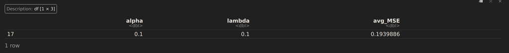

Wyniki walidacji krzyżowej

## $c)$ Wykresy skrzypcowe dla MSE

Przygotowujemy dane do rysowania wykresów skrzypcowych.

```r
mse_all <- data.frame(alpha = numeric(), lambda = numeric(), MSE = numeric())

for (i in seq(1, length(results), by = 2)) {
    alpha_value <- results[[i]]
    lambda_results <- results[[i + 1]]

    for (lambda_name in names(lambda_results)) {
        lambda_value <- as.numeric(sub("Lambda ", "", lambda_name))
        mse_values <- unlist(lambda_results[[lambda_name]])

        for (mse in mse_values) {
            mse_all <- rbind(mse_all, data.frame(alpha = alpha_value, lambda = lambda_value, MSE = mse))
        }
    }
}

print(head(mse_all))

mse_plot <- mse_all %>%
  mutate(alpha_lambda = paste("λ =", format(round(lambda, 3), nsmall = 3)))
```

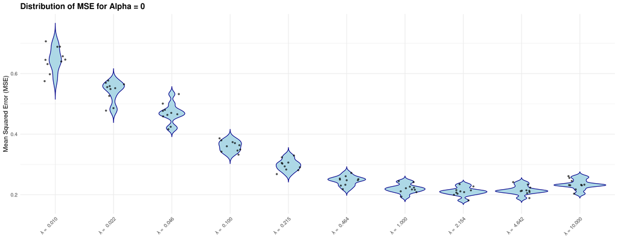

Wykres skrzypcowy dla $\alpha = 0$

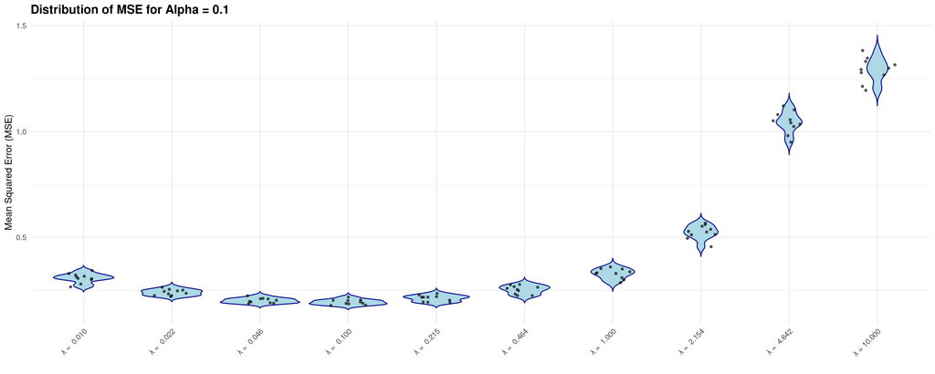

Wykres skrzypcowy dla $\alpha = 0.1$

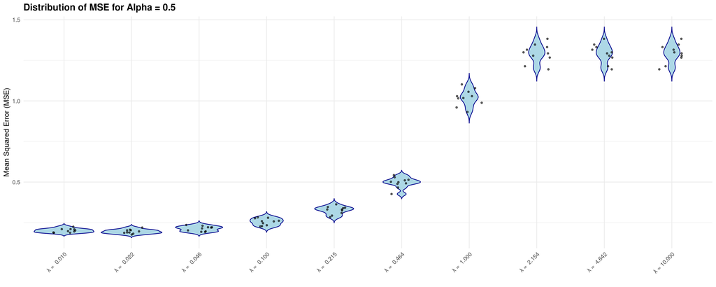

Wykres skrzypcowy dla $\alpha = 0.5$

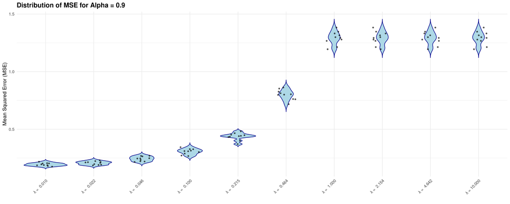

Wykres skrzypcowy dla $\alpha = 0.9$

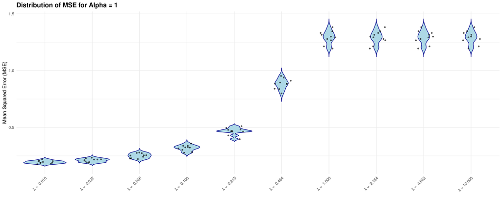

Wykres skrzypcowy dla $\alpha = 1$

```r
unique_alphas <- unique(mse_plot$alpha)

plots <- list()
for (alpha in unique_alphas) {
  data_subset <- mse_plot[mse_plot$alpha == alpha, ]

  p <- ggplot(data_subset, aes(x = alpha_lambda, y = MSE)) +
    geom_violin(trim = FALSE, fill = "lightblue", color = "darkblue") +
    geom_point(position = position_jitter(width = 0.2), size = 1.0, alpha = 0.6) +
    labs(title = paste("Distribution of MSE for Alpha =", alpha),
         x = "",
         y = "Mean Squared Error (MSE)") +
    theme_minimal() +
    theme(axis.text.x = element_text(angle = 45, hjust = 1),
          plot.title = element_text(size = 14, face = "bold"),
          legend.position = "none")

  plots[[paste("Alpha", alpha)]] <- p
}

for (plot in plots)
    print(plot)
```

## $d)$ Błąd treningowy i walidacyjny dla optymalnych hiperparametrów

```r
best_alpha <- 0.1
best_lambda <- 0.1
sum_mse_test_net <- 0
sum_mse_train_net <- 0

# Dopasowujemy model dla najlepszych wartości hiperparametrów
for (i in seq_along(folds)) {
      fold <- folds[[i]]

      train_indices <- fold$train
      test_indices <- fold$test

      # Dzielimy dane na foldy
      X_train_fold <- as.matrix(X_train[train_indices, , drop = FALSE])
      Y_train_fold <- Y_train[train_indices, ]
      X_test_fold <- as.matrix(X_train[test_indices, , drop = FALSE])
      Y_test_fold <- Y_train[test_indices, ]

      # Dopasowujemy model ElasticNet
      model <- glmnet(X_train_fold, Y_train_fold, alpha = best_alpha, lambda = best_lambda)

      # Predykcje dla zbioru treningowego i testowego
      train_predictions <- predict(model, s = best_lambda, newx = X_train_fold)
      test_predictions <- predict(model, s = best_lambda, newx = X_test_fold)

      # Obliczamy MSE dla zbioru treningowego i testowego
      mse_train <- mean((Y_train_fold - train_predictions)^2)
      mse_test <- mean((Y_test_fold - test_predictions)^2)

      sum_mse_train_net <- sum_mse_train_net + mse_train
      sum_mse_test_net <- sum_mse_test_net + mse_test
}
```

```r
# Obliczamy MSE uśrednionego po wszystkich foldach
fold_count <- length(folds)
avg_mse_train_net <- sum_mse_train_net / fold_count
avg_mse_test_net <- sum_mse_test_net / fold_count

cat("Average Training MSE:", avg_mse_train_net, "\n")
```

```
## Average Training MSE: 0.1417782
```

```r
cat("Average Validation MSE:", avg_mse_test_net)
```

```
## Average Validation MSE: 0.1939886
```

# 4. Lasy losowe

W tej części projektu trenujemy model lasów losowych.

## $a)$ Walidacja krzyżowa

Zdefiniujmy najpierw siatkę hiperparametrów. W tym projekcie wybrałem liczbę drzew (*num_trees*), maksymalną głębokość każdego drzewa (*max_depth*) oraz *mtry*.

```r
num_trees <- c(100, 200, 300, 400)  # Liczba drzew
max_depth <- c(10, 20, 30, 40)  # Maksymalna głębokość każdego drzewa
mtry_default <- round(sqrt(ncol(X_train)))  # Domyślna wartość 'mtry' to sqrt(liczba zmiennych)

mtry_values <- c(50, mtry_default, 150, 200)
```

Wykonajmy teraz walidację krzyżową.

```r
num_rows <- length(num_trees) * length(max_depth) * length(mtry_values) * length(folds)
# Wyniki CV
results_df <- data.frame(
  fold_i = integer(num_rows),
  num_trees = integer(num_rows),
  depth = integer(num_rows),
  mtry = integer(num_rows),
  MSE = numeric(num_rows)
)

counter <- 1
for (trees in num_trees) {
  for (depth in max_depth) {
    for (mtry in mtry_values) {
      for (i in seq_along(folds)) {
        fold <- folds[[i]]

        train_indices <- fold$train
        test_indices <- fold$test

        # Dzielimy dane na foldy
        X_train_fold <- as.matrix(X_train[train_indices, , drop = FALSE])
        Y_train_fold <- Y_train[train_indices, ]
        X_test_fold <- as.matrix(X_train[test_indices, , drop = FALSE])
        Y_test_fold <- Y_train[test_indices, ]

        # Dopasowujemy las losowy
        model <- ranger(
          formula         = Y ~ .,
          data            = data.frame(Y = Y_train_fold, X_train_fold),
          num.trees       = trees,
          mtry            = mtry,
          max.depth       = depth,
          seed            = 1000,         # Dla powtarzalności
          verbose         = TRUE,         # Postępy obliczeń
          num.threads     = 7
        )

        # Predykcje dla zbioru testowego
        predictions <- predict(model, data.frame(X_test_fold))$predictions

        # Obliczamy MSE dla foldu testowego
        mse_value <- mean((Y_test_fold - predictions)^2)

        # Wyniki zapisujemy we wcześniej zdefiniowanej ramce danych
        results_df[counter, ] <- c(i, trees, depth, mtry, mse_value)
        counter <- counter + 1
        print(counter)
      }
    }
  }
}
```

Oglądamy przykładowe wyniki walidacji krzyżowej oraz zapisujemy je w pliku CSV dla późniejszego wykorzystania.

```r
head(results_df)

write.csv(results_df, "random_forest_cv_results.csv", row.names = FALSE)
```

Znajdujemy najlepszy zestaw hiperparametrów na podstawie walidacji krzyżowej.

```r
# Obliczamy średnie MSE po wszystkich foldach testowych dla danego zestawu parametrów.
results_df <- readr::read_csv("random_forest_cv_results.csv")
average_mse <- results_df %>%
    group_by(num_trees, depth, mtry) %>%
    summarise(avg_MSE = mean(MSE), .groups = 'drop')

best_row <- which.min(average_mse$avg_MSE)
print(average_mse[best_row, ])
```

```
## # A tibble: 1 × 4
##   num_trees depth  mtry avg_MSE
##       <dbl> <dbl> <dbl>   <dbl>
## 1       300    30   200   0.193
```

## $b)$ Wykres pudełkowy

Dla poprawy czytelności wykresu pudełkowego zostały stworzone $4$ oddzielne wykresy - każdy wykres zawiera stałą liczbę drzew, zmienne są parametry głębokości drzewa oraz *mtry*.

Dodatkowo, na każdym wykresie pudełka są pokolorowane ze względu na parametr głębokości drzewa (*depth*).

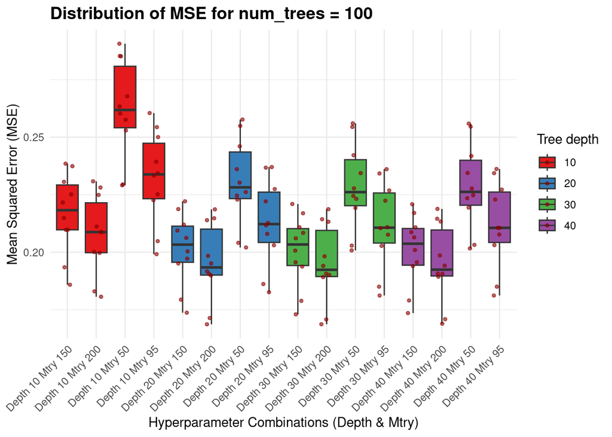

```r
box_plots <- list()
for (number_of_trees in num_trees) {
  # Filtrujemy dane ze względu na liczbę drzew
  data_subset <- results_df[results_df$num_trees == number_of_trees, ]

  # Tworzymy wykres pudełkowy dla danej liczby drzew
  p <- ggplot(data_subset, aes(x = factor(paste("Depth", depth, "Mtry", mtry)), y = MSE, fill = factor(depth))) +
    geom_boxplot() +
    geom_jitter(color = "darkred", size = 1.0, width = 0.2, alpha = 0.6) +
    scale_fill_brewer(palette = "Set1", name = "Tree depth") +
    labs(title = paste("Distribution of MSE for num_trees =", number_of_trees),
         x = "Hyperparameter Combinations (Depth & Mtry)",
         y = "Mean Squared Error (MSE)") +
    theme_minimal() +
    theme(axis.text.x = element_text(angle = 45, hjust = 1, vjust = 1),
          plot.title = element_text(size = 14, face = "bold"),
          legend.position = "right")

  # Wykresy tworzą listę, gdzie liczba drzew służy jako klucz
  box_plots[[number_of_trees]] <- p
}

# Liczba drzew jest kluczem w liście wykresów
print(box_plots[[100]])
```

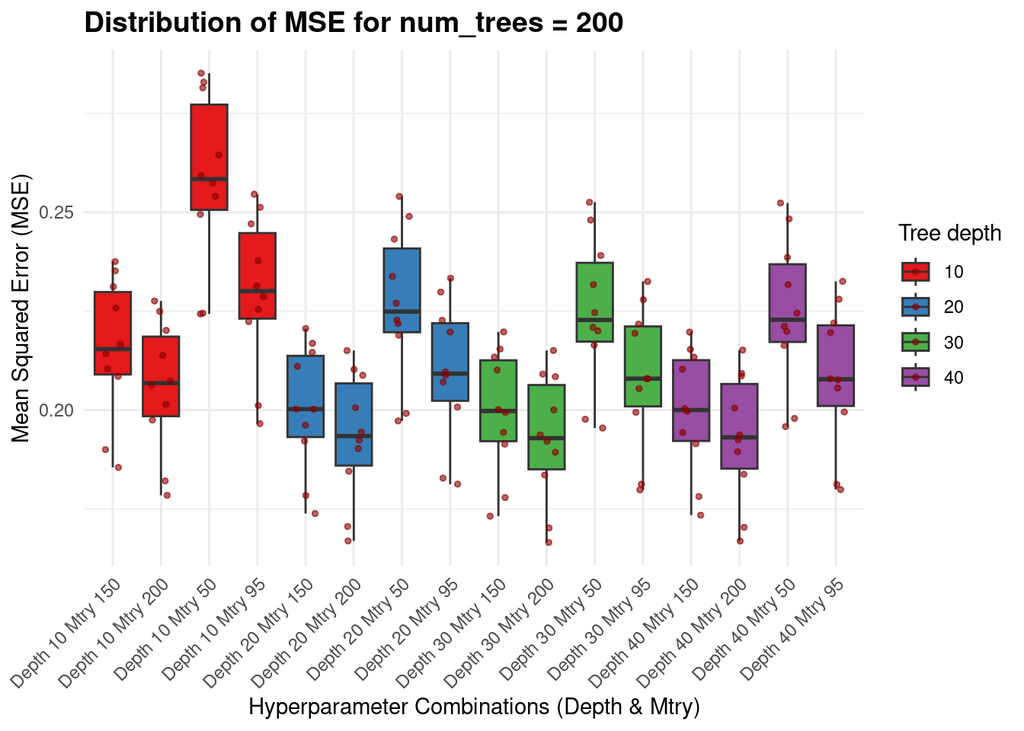

```r
print(box_plots[[200]])
```

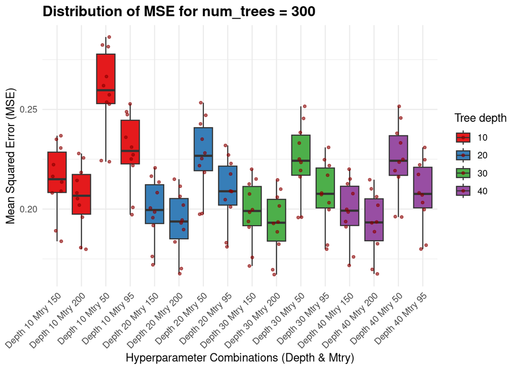

```r
print(box_plots[[300]])
```

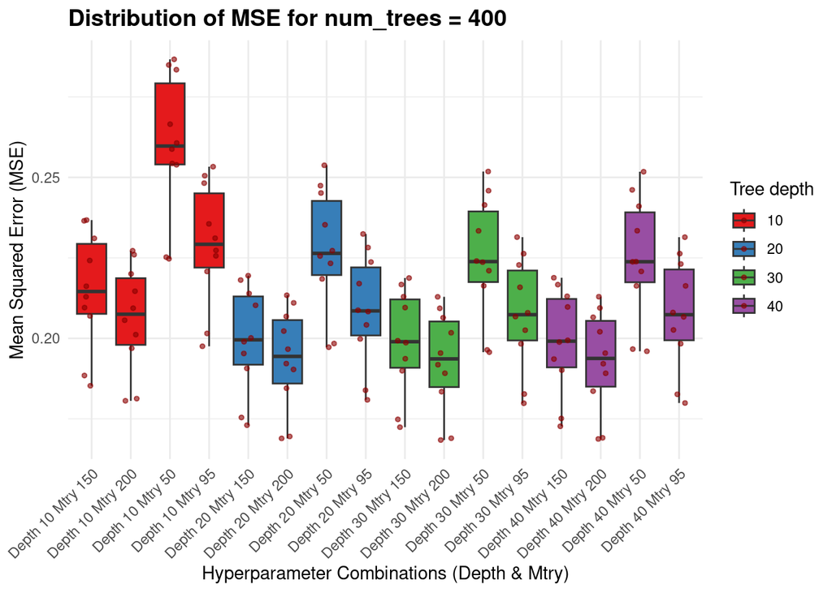

```r
print(box_plots[[400]])
```

## $c)$ Błąd treningowy i walidacyjny dla wybranych wartości hiperparametrów

```r
print(average_mse[best_row, ])
```

```
## # A tibble: 1 × 4
##   num_trees depth  mtry avg_MSE
##       <dbl> <dbl> <dbl>   <dbl>
## 1       300    30   200   0.193
```

```r
best_num_trees <- average_mse[best_row, ]$num_trees
best_depth <- average_mse[best_row, ]$depth
best_mtry <- average_mse[best_row, ]$mtry

sum_mse_train <- 0
sum_mse_test <- 0
fold_count <- length(folds)
```

```r
for (i in seq_along(folds)) {
    fold <- folds[[i]]

    train_indices <- fold$train
    test_indices <- fold$test

    # Dzielimy dane na foldy
    X_train_fold <- as.matrix(X_train[train_indices, , drop = FALSE])
    Y_train_fold <- Y_train[train_indices, ]
    X_test_fold <- as.matrix(X_train[test_indices, , drop = FALSE])
    Y_test_fold <- Y_train[test_indices, ]

    # Dopasowujemy las losowy
    model <- ranger(
        formula         = Y ~ .,
        data            = data.frame(Y = Y_train_fold, X_train_fold),
        num.trees       = best_num_trees,
        mtry            = best_mtry,
        max.depth       = best_depth,
        seed            = 1000,         # Dla powtarzalności
        verbose         = TRUE,         # Postępy obliczeń
        num.threads     = 7
    )

    # Predykcje dla zbioru treningowego i testowego
    train_predictions <- predict(model, data.frame(X_train_fold))$predictions
    test_predictions <- predict(model, data.frame(X_test_fold))$predictions

    # Obliczamy MSE dla zbioru treningowego i testowego
    mse_train <- mean((Y_train_fold - train_predictions)^2)
    mse_test <- mean((Y_test_fold - test_predictions)^2)

    sum_mse_train <- sum_mse_train + mse_train
    sum_mse_test <- sum_mse_test + mse_test
}
```

```r
# Obliczamy MSE uśrednionego po wszystkich foldach
avg_mse_train <- sum_mse_train / fold_count
avg_mse_test <- sum_mse_test / fold_count

cat("Average Training MSE:", avg_mse_train, "\n")
cat("Average Validation MSE:", avg_mse_test)
```

[output not shown]

Otrzymaliśmy błąd treningowy na poziomie ok. 0.035 oraz błąd walidacyjny na poziomie ok. 0.193 Widzimy, że błąd treningowy jest istotnie mniejszy od błędy walidacyjnego, co może sugerować pewne przeuczenie modelu.

# 5. Podsumowanie

Najpierw dopasujmy prosty model referencyjny, który dowolnym wartościom zmiennych objaśniających w foldzie testowym przypisuje średnią arytmetyczną zmiennej objaśnianej policzoną w foldach treningowych.

```r
sum_mse_train_ref <- 0
sum_mse_test_ref <- 0
fold_count <- length(folds)

for (i in seq_along(folds)) {
    fold <- folds[[i]]

    train_indices <- fold$train
    test_indices <- fold$test

    # Dzielimy dane na foldy
    X_train_fold <- as.matrix(X_train[train_indices, , drop = FALSE])
    Y_train_fold <- Y_train[train_indices, ]
    X_test_fold <- as.matrix(X_train[test_indices, , drop = FALSE])
    Y_test_fold <- Y_train[test_indices, ]

    # Dopasowujemy nasz model referencyjny
    y_train_avg <- mean(Y_train_fold)

    # Predykcje dla zbioru treningowego i testowego
    train_predictions <- rep(y_train_avg, length(Y_train_fold))
    test_predictions <- rep(y_train_avg, length(Y_test_fold))

    # Obliczamy MSE dla zbioru treningowego i testowego
    mse_train <- mean((Y_train_fold - train_predictions)^2)
    mse_test <- mean((Y_test_fold - test_predictions)^2)

    sum_mse_train_ref <- sum_mse_train_ref + mse_train
    sum_mse_test_ref <- sum_mse_test_ref + mse_test
}
```

```r
# Obliczamy MSE uśrednionego po wszystkich foldach
avg_mse_train_ref <- sum_mse_train_ref / fold_count
avg_mse_test_ref <- sum_mse_test_ref / fold_count

cat("Average Training MSE for Reference Model:", avg_mse_train_ref, "\n")
```

```
## Average Training MSE for Reference Model: 1.291962
```

```r
cat("Average Validation MSE for Reference Model:", avg_mse_test_ref, "\n")
```

```
## Average Validation MSE for Reference Model: 1.292329
```

Błąd średniokwadratowy walidacyjny oraz treningowy modelu referencyjnego są bardzo zbliżone do siebie, jednak o wiele gorsze od wartości uzyskanych dla modeli *ElasticNet* oraz lasów losowych.

```r
mse_data <- data.frame(
    Model = c("ElasticNet", "Random Forest", "Ref. model"),
    Train_MSE = c(avg_mse_train_net, 0.0346, avg_mse_train_ref),
    Test_MSE = c(avg_mse_test_net, 0.1926, avg_mse_test_ref)
)

print(mse_data)
```

```
##           Model Train_MSE  Test_MSE
## 1    ElasticNet 0.1417782 0.1939886
## 2 Random Forest 0.0346000 0.1926000
## 3    Ref. model 1.2919620 1.2923286
```

Uważam, że przy uzyskanych wynikach najlepszy model to *ElasticNet* z uwagi na zbliżone wartości $MSE$ do modelu lasów losowych. Dodatkowo model *ElasticNet* jest o wiele mniej wymagający obliczeniowo oraz jest łatwiej wyjaśnialny. Lasy losowe prawdopodobnie poradziły by sobie lepiej dla poszerzonej siatki hiperparametrów przeszukiwanych podczas walidacji krzyżowej.